# Did the Industrial Revolution Cause Global Warming?

*The first exploratory portion of this project was completed in Python, in the Industrial_Revolution.ipynb file*

Load libraries:

```r
library(tidyverse)
library(lubridate)
library(rdrobust)
library(ggplot2)
library(rdd)
```

```
Error in library(rdd) : there is no package called ‘rdd’
```

Load Data cleaned and reformmated in Python:

```r
yearly_temps <-  read_csv("GlobalTemperaturesCleaned.csv")
print(head(yearly_temps))
```

| ...1 | year | avg_temp | uncertainty | Industrial_Revolution |
| --- | --- | --- | --- | --- |
| 0 | 1750 | 8.719364 | 0.8168423 | FALSE |
| 1 | 1751 | 7.976143 | 1.0801121 | FALSE |
| 2 | 1752 | 5.779833 | 1.2283530 | FALSE |
| 3 | 1753 | 8.388083 | 0.9701339 | FALSE |
| 4 | 1754 | 8.469333 | 1.0910630 | FALSE |
| 5 | 1755 | 8.355583 | 1.1534296 | FALSE |

Now that we have the data, we can check that it has been imported and formatted correctly

```r
print(str(yearly_temps))
```

```
spc_tbl_ [266 × 5] (S3: spec_tbl_df/tbl_df/tbl/data.frame)
 $ ...1                 : num [1:266] 0 1 2 3 4 5 6 7 8 9 ...
 $ year                 : num [1:266] 1750 1751 1752 1753 1754 ...
 $ avg_temp             : num [1:266] 8.72 7.98 5.78 8.39 8.47 ...
 $ uncertainty          : num [1:266] 0.817 1.08 1.228 0.97 1.091 ...
 $ Industrial_Revolution: logi [1:266] FALSE FALSE FALSE FALSE FALSE FALSE ...
 - attr(*, "spec")=
  .. cols(
  ..   ...1 = col_double(),
  ..   year = col_double(),
  ..   avg_temp = col_double(),
  ..   uncertainty = col_double(),
  ..   Industrial_Revolution = col_logical()
  .. )
 - attr(*, "problems")=<externalptr>
NULL
```

It looks like everything is as expected - the numerical data are the *num* data type, and the column representing whether a year is pre- or post- Industrial Revolution are *logic* values.

## Plot a chart of the data with the cutoff date of 1840

Following the EDA in Python, we are using the yearly data to reduce the noise and make the trends easier to identify. Let’s plot the data showing the widely accepted cut off point of the Revolution at 1840:

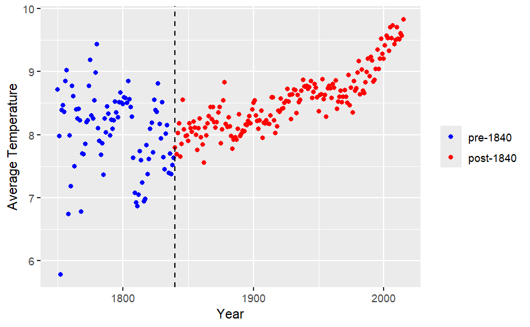

```r
temp_plot <- yearly_temps %>% ggplot(aes(x = year,y = avg_temp, color = Industrial_Revolution))+
  geom_point()+
  xlab("Year")+
  ylab("Average Temperature")+
  scale_color_manual(
    values = c("FALSE" = "blue", "TRUE" = "red"),
    labels = c("FALSE" = "pre-1840", "TRUE" = "post-1840"),
    name = NULL
  ) + geom_vline(xintercept = 1840, linetype = "dashed")

temp_plot
```

Let’s now create a regression line for the data either side of the cut off point to see if there is a noticeable difference and to inform which method of RDA should be applied here.

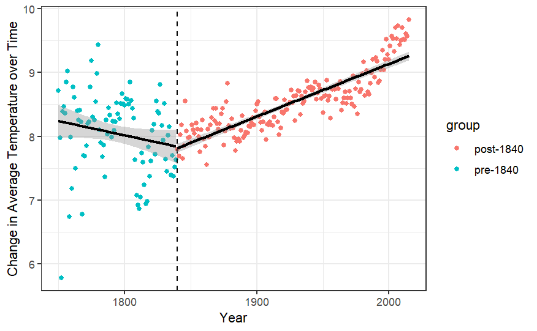

```r
#first grouping the data fore pre-1840 and post-1840
yearly_temps_grouped  <- yearly_temps %>%  mutate(group = case_when( year < 1840 ~ "pre-1840", year >= 1840 ~ "post-1840"))

#creating the plots
yearly_temps_plots <- yearly_temps_grouped %>% ggplot(aes(x=year, y =avg_temp, color = group)) +
  geom_point() + theme_bw() + xlab("Year") + ylab("Change in Average Temperature over Time") +
  geom_vline(xintercept = 1840, linetype = "dashed") +
  geom_smooth(aes(group = group), color = "black", method = lm)

yearly_temps_plots
```

## Regression Discontinuity Analysis

The first step is to select the bandwidth we will be using around the cutoff point. The `rdrobust` package is sufficient to create an appropriate bandwidth.

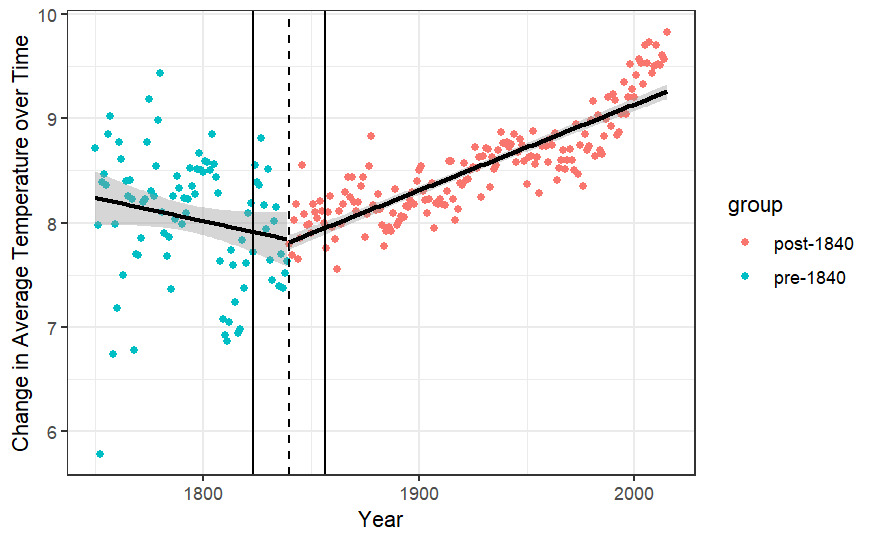

```r
bandwidths <- (rdbwselect(y=yearly_temps$avg_temp, x= yearly_temps$year, c = 1840)) #deriv = 1 indicates that this is for a kink RDA

bw <- bandwidths$bws[1][1] # store the bandwidth value as a variable

yearly_temps_plots + geom_vline(xintercept = 1840 + c(bw, -bw))
```

```r
bw
```

```
[1] 16.7177
```

We can create a new plot that only include the data within the bandwidths to get a closer look

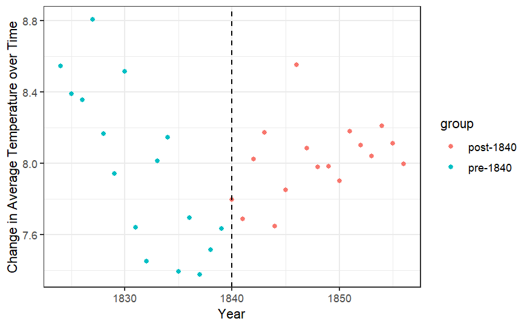

```r
yearly_temps_bw <- yearly_temps_grouped %>% filter((year > 1840 -bw) & year < 1840+bw)

bandwidth_plot <- yearly_temps_bw %>% ggplot(aes(x=year, y =avg_temp, color = group)) + geom_point() + theme_bw() + xlab("Year") + ylab("Change in Average Temperature over Time") +
  geom_vline(xintercept = 1840, linetype = "dashed")

bandwidth_plot
```

Now let’s add the regression lines for this selected section of the data:

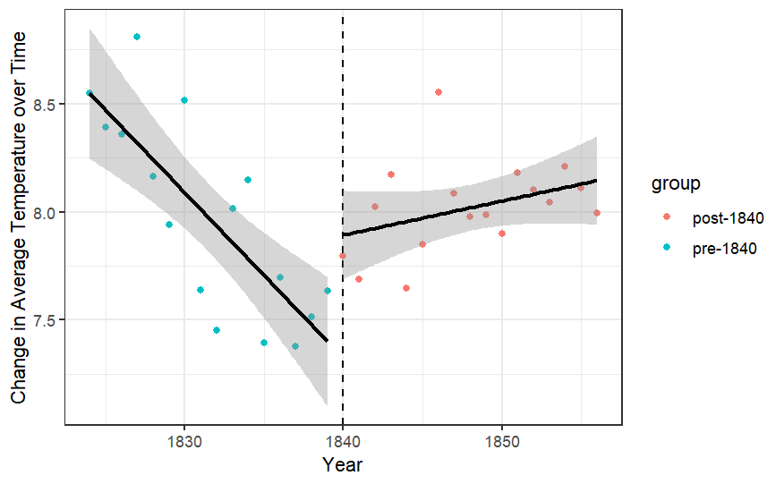

```r
bandwidth_regressions <- bandwidth_plot + geom_smooth(data = yearly_temps_bw, aes(x= year, y = avg_temp, group = group), color = "black", method = lm)
bandwidth_regressions
```

## Performing RDA

The data is prepared and we can now carry out the analysis.

```r
rda <- rdrobust(y=yearly_temps_grouped$avg_temp, x= yearly_temps_grouped$year, c = 1840)

print(rda)
```

```
Call: rdrobust

Number of Obs.                  266
BW type                       mserd
Kernel                   Triangular
VCE method                       NN

Number of Obs.                   90          176
Eff. Number of Obs.              16           17
Order est. (p)                    1            1
Order bias  (q)                   2            2
BW est. (h)                  16.718       16.718
BW bias (b)                  35.576       35.576
rho (h/b)                     0.470        0.470
Unique Obs.                      90          176
```

Printing the rda shows that there are a total of 90 observations before the year 1840 and 176 observations after the year 1840. The Effective Number of Observations demonstrates that 16 observations were within the bandwidth to the left of the year 1840 and 17 observations were within the bandwidth to the right of the year 1840.

Let’s now check the coefficients of the analysis:

```r
rda$coef
```

```
                   Coeff
Conventional   0.4874899
Bias-Corrected 0.6070984
Robust         0.6070984
```

```r
rda$se
```

```
               Std. Err.
Conventional   0.1512726
Bias-Corrected 0.1512726
Robust         0.1642058
```

The difference in predicted values at the cutoff of 1840 from the local regressions on either side, using the chosen bandwidth was about 0.61 (for the bias corrected calculation)

The standard error of the this gives an indication of how meaningful this difference is, and gives an error of 0.15. Even when accounting for this error, the ATE will still not be near to 0 - suggesting that the treatment variable does lead to a jump in the outcome.

Finding the p-value will give a more decisive judgement of the results:

```r
rda$pv
```

```
                      P>|z|
Conventional   1.270360e-03
Bias-Corrected 5.988216e-05
Robust         2.180083e-04
```

Assuming a threshold 0f 0.05, the p-value is lower than required and we can therefore conclude the the jump at the cutoff point created by the differing regression lines is statistically significant.

# Conclusions

The results of the analysis show that there is a causal relationship between the Industrial Revolution and the rise in global temperatures. This result matches the models and predictions made by climate scientists that the rise of industry and the resulting excess greenhouse gases is causing global warming.

The results are a major cause for concern and should be used to inform corporations of the dangers of continual release of harmful pollutants.

That being said, it is impossible for such a study to analyse this data in isolation and assume that there are no other variables that could be affecting the global temperatures. The climate and global systems are extremely complex, and there are limits to the statistical inferences we can make from this data. For example, this dataset only extends as far back as the 1750s. Trends in the climate over vast geological time scales and ice age cycles should be taken into account to identify if the current trend is anomalous compared what we should expect in the current geological period.

In addition to the assumption that there are no other variables driving the global temperatures, we have no viable counterfactual model that we can use - we can not imagine an Earth where the Industrial Revolution did not happen.

These factors provide limits to our investigation, but the analysis does strongly suggest that the rise of industry led to increasing average global temperatures.